# Lesson 1 Assignment - EnergyLoads

## Author - AlexSkrn

### Instructions

In this exercise you will use visualization and summary statistical methods to explore a data set. You will be looking for interesting aspects in these data. Specifically, you will explore an energy efficiency data set.

This data set contains characteristics of over 750 buildings. The efficiency of the building is measured as either heating load or cooling load. Your goal is to find **three interesting relationships within the variables** which help you understand the energy efficiency of these buildings.

The exercise is deliberately open-ended. Whenever you approach a new data set some open-ended exploration is required. Expect this exploration to be an iterative process. You may need to try several ideas before you find truly interesting relationships.

The key points come from examining charts and summary statistics based on distribution Heating Load and Cooling Load. At the end of this notebook include Markdown cells outlining your 3 key points.

Example description: The heating load of buildings depends on ... Evidence for this relationship can be seen by ... in the figure and by noting .... in the table above.

#### Tip:

```python
# Import libraries
import pandas as pd
import numpy as np
import matplotlib.pyplot as plt
%matplotlib inline
```

```python
# Cleaned up Dataset location
fileName = "https://library.startlearninglabs.uw.edu/DATASCI410/Datasets/EnergyEfficiencyData.csv"

## Read the .csv file with the pandas read_csv method
energy_loads = pd.read_csv(fileName)
```

```python
# Look at the dataframe shape, data types and the number of unique values in each column
print(energy_loads.shape)
dtypes_unique_vals = pd.DataFrame({'dtypes': energy_loads.dtypes})  # Create a dataframe of dtypes to print prettily
unique_vals = []
for var in energy_loads.columns:
    unique_vals.append(len(energy_loads.loc[:, var].unique()))
dtypes_unique_vals['unique_vals'] = unique_vals  # Add the number of unique values to this dataframe
print(dtypes_unique_vals)
```

```
(768, 10)
                            dtypes  unique_vals
Relative Compactness       float64           12
Surface Area               float64           12
Wall Area                  float64            7
Roof Area                  float64            4
Overall Height             float64            2
Orientation                  int64            4
Glazing Area               float64            4
Glazing Area Distribution    int64            6
Heating Load               float64          586
Cooling Load               float64          636
```

```python
# Look at the summary statistics for this data set
energy_loads.describe()
```

|  | Relative Compactness | Surface Area | Wall Area | Roof Area | Overall Height | Orientation | Glazing Area | Glazing Area Distribution | Heating Load | Cooling Load |
| --- | --- | --- | --- | --- | --- | --- | --- | --- | --- | --- |
| count | 768.000000 | 768.000000 | 768.000000 | 768.000000 | 768.00000 | 768.000000 | 768.000000 | 768.00000 | 768.000000 | 768.000000 |
| mean | 0.764167 | 671.708333 | 318.500000 | 176.604167 | 5.25000 | 3.500000 | 0.234375 | 2.81250 | 22.307201 | 24.587760 |
| std | 0.105777 | 88.086116 | 43.626481 | 45.165950 | 1.75114 | 1.118763 | 0.133221 | 1.55096 | 10.090196 | 9.513306 |
| min | 0.620000 | 514.500000 | 245.000000 | 110.250000 | 3.50000 | 2.000000 | 0.000000 | 0.00000 | 6.010000 | 10.900000 |
| 25% | 0.682500 | 606.375000 | 294.000000 | 140.875000 | 3.50000 | 2.750000 | 0.100000 | 1.75000 | 12.992500 | 15.620000 |
| 50% | 0.750000 | 673.750000 | 318.500000 | 183.750000 | 5.25000 | 3.500000 | 0.250000 | 3.00000 | 18.950000 | 22.080000 |
| 75% | 0.830000 | 741.125000 | 343.000000 | 220.500000 | 7.00000 | 4.250000 | 0.400000 | 4.00000 | 31.667500 | 33.132500 |
| max | 0.980000 | 808.500000 | 416.500000 | 220.500000 | 7.00000 | 5.000000 | 0.400000 | 5.00000 | 43.100000 | 48.030000 |

```python
# Look at the first and last few lines of the dataframe
energy_loads.head()
```

|  | Relative Compactness | Surface Area | Wall Area | Roof Area | Overall Height | Orientation | Glazing Area | Glazing Area Distribution | Heating Load | Cooling Load |
| --- | --- | --- | --- | --- | --- | --- | --- | --- | --- | --- |
| 0 | 0.98 | 514.5 | 294.0 | 110.25 | 7.0 | 2 | 0.0 | 0 | 15.55 | 21.33 |
| 1 | 0.98 | 514.5 | 294.0 | 110.25 | 7.0 | 3 | 0.0 | 0 | 15.55 | 21.33 |
| 2 | 0.98 | 514.5 | 294.0 | 110.25 | 7.0 | 4 | 0.0 | 0 | 15.55 | 21.33 |
| 3 | 0.98 | 514.5 | 294.0 | 110.25 | 7.0 | 5 | 0.0 | 0 | 15.55 | 21.33 |
| 4 | 0.90 | 563.5 | 318.5 | 122.50 | 7.0 | 2 | 0.0 | 0 | 20.84 | 28.28 |

```python
energy_loads.tail()
```

|  | Relative Compactness | Surface Area | Wall Area | Roof Area | Overall Height | Orientation | Glazing Area | Glazing Area Distribution | Heating Load | Cooling Load |
| --- | --- | --- | --- | --- | --- | --- | --- | --- | --- | --- |
| 763 | 0.64 | 784.0 | 343.0 | 220.5 | 3.5 | 5 | 0.4 | 5 | 17.88 | 21.40 |
| 764 | 0.62 | 808.5 | 367.5 | 220.5 | 3.5 | 2 | 0.4 | 5 | 16.54 | 16.88 |
| 765 | 0.62 | 808.5 | 367.5 | 220.5 | 3.5 | 3 | 0.4 | 5 | 16.44 | 17.11 |
| 766 | 0.62 | 808.5 | 367.5 | 220.5 | 3.5 | 4 | 0.4 | 5 | 16.48 | 16.61 |
| 767 | 0.62 | 808.5 | 367.5 | 220.5 | 3.5 | 5 | 0.4 | 5 | 16.64 | 16.03 |

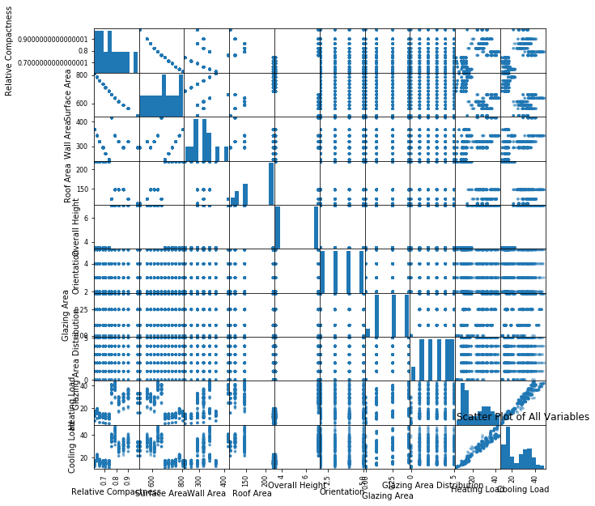

```python
# Create a scatter plot of all variables to see if there is anything immediately worth investigating
pd.plotting.scatter_matrix(energy_loads, figsize=[10, 10], s=50)
plt.title('Scatter Plot of All Variables')
```

From this scatter plot, the variables worth investigating in the first place include Heating Load and Cooling Load; Relative Compactness and Surface Area, because they seem to have strong relationships.

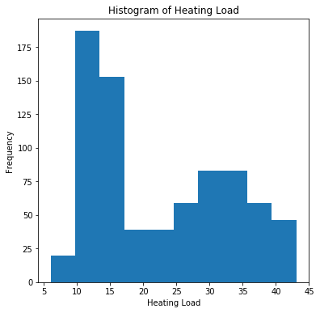

```python
# Create a histogram of Heating Load
fig = plt.figure(figsize=(6, 6)) # Define plot area
ax = fig.gca() # Define axis
plt.hist(energy_loads.loc[:, 'Heating Load'])
ax.set_title('Histogram of Heating Load') # Give the plot a main title
ax.set_xlabel('Heating Load')# Set text for y axis
ax.set_ylabel('Frequency')# Set text for y axis
```

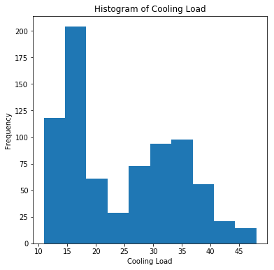

```python
# Create a histogram of Cooling Load
fig = plt.figure(figsize=(6, 6)) # Define plot area
ax = fig.gca() # Define axis
plt.hist(energy_loads.loc[:, 'Cooling Load'])
ax.set_title('Histogram of Cooling Load') # Give the plot a main title
ax.set_xlabel('Cooling Load')# Set text for y axis
ax.set_ylabel('Frequency')# Set text for y axis
```

```
(0.0, 50.0)
```

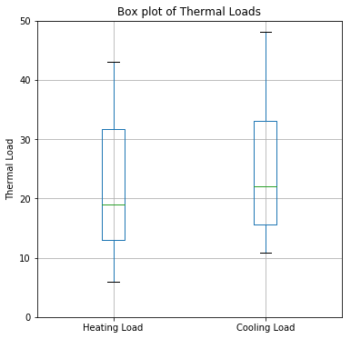

```python
# Create a box plot for the two thermal load types - Heating Load and Cooling Load - to see how they compare
fig = plt.figure(figsize=(6, 6)) # Define plot area
ax = fig.gca() # Define axis
energy_loads.loc[:,['Heating Load', 'Cooling Load']].boxplot(ax = ax)
ax.set_title('Box plot of Thermal Loads') # Give the plot a main title
ax.set_ylabel('Thermal Load')# Set text for y axis
ax.set_ylim(0.0, 50.0) # Set the limits of the y axis
```

From the general scatter plot above and from the **thermal loads box plot** immediately above it seems that these two types of thermal load are very much alike so it shouldn't matter which one to use in the data exploration. For simplicity, I will use the Heating Load only.

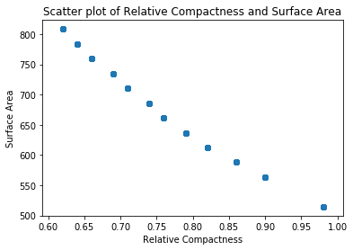

```python
# Because, from the scatter plot in the beginning, Relative Compactness and Surface Area seem too much related
# to each other, let's create a scatter plot for them
plt.scatter(energy_loads.loc[:, 'Relative Compactness'],
                energy_loads.loc[:, 'Surface Area'])
plt.xlabel('Relative Compactness')
plt.ylabel('Surface Area')
plt.title('Scatter plot of Relative Compactness and Surface Area')
```

The **compactness-vs-surface area scatter plot** above shows a strong relationship between the Relative Compactness and Surface Area.

```python
# and create a cross table of Relative Compactness and Surface Area
pd.crosstab(index=energy_loads['Relative Compactness'].astype("str"),
            columns=energy_loads['Surface Area'].astype("str")
            )
```

| Surface Area Relative Compactness | 514.5 | 563.5 | 588.0 | 612.5 | 637.0 | 661.5 | 686.0 | 710.5 | 735.0 | 759.5 | 784.0 | 808.5 |
| --- | --- | --- | --- | --- | --- | --- | --- | --- | --- | --- | --- | --- |
| 0.62 | 0 | 0 | 0 | 0 | 0 | 0 | 0 | 0 | 0 | 0 | 0 | 64 |
| 0.64 | 0 | 0 | 0 | 0 | 0 | 0 | 0 | 0 | 0 | 0 | 64 | 0 |
| 0.66 | 0 | 0 | 0 | 0 | 0 | 0 | 0 | 0 | 0 | 64 | 0 | 0 |
| 0.69 | 0 | 0 | 0 | 0 | 0 | 0 | 0 | 0 | 64 | 0 | 0 | 0 |
| 0.71 | 0 | 0 | 0 | 0 | 0 | 0 | 0 | 64 | 0 | 0 | 0 | 0 |
| 0.74 | 0 | 0 | 0 | 0 | 0 | 0 | 64 | 0 | 0 | 0 | 0 | 0 |
| 0.76 | 0 | 0 | 0 | 0 | 0 | 64 | 0 | 0 | 0 | 0 | 0 | 0 |
| 0.79 | 0 | 0 | 0 | 0 | 64 | 0 | 0 | 0 | 0 | 0 | 0 | 0 |
| 0.82 | 0 | 0 | 0 | 64 | 0 | 0 | 0 | 0 | 0 | 0 | 0 | 0 |
| 0.86 | 0 | 0 | 64 | 0 | 0 | 0 | 0 | 0 | 0 | 0 | 0 | 0 |
| 0.9 | 0 | 64 | 0 | 0 | 0 | 0 | 0 | 0 | 0 | 0 | 0 | 0 |
| 0.98 | 64 | 0 | 0 | 0 | 0 | 0 | 0 | 0 | 0 | 0 | 0 | 0 |

From both the scatter plot and the **cross table** above, it is clear that there is an inverse linear dependence between Relative Compactness and Surface Area. These two variables must contain the same data. They must have been a result of binning into 12 bins with 64 values in each bin.

### I will now look at the charts of all of the variables to see how they relate to the Heating Load

(except for the Relative Compactnes because it does not add anything new compared to the Surface Area)

```
(0.0, 50.0)
```

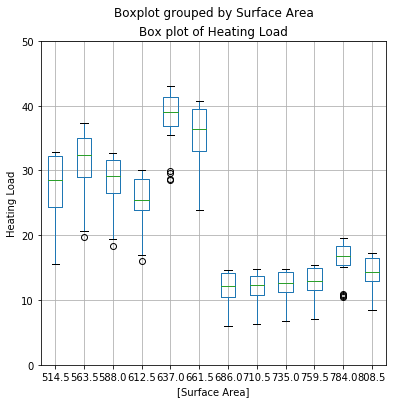

```python
# Create a box plot of Heating Load grouped by Surface Area
fig = plt.figure(figsize=(6, 6)) # Define plot area
ax = fig.gca() # Define axis
energy_loads.loc[:,['Heating Load', 'Surface Area']].boxplot(by = 'Surface Area', ax = ax)
ax.set_title('Box plot of Heating Load') # Give the plot a main title
ax.set_ylabel('Heating Load')# Set text for y axis
ax.set_ylim(0.0, 50.0) # Set the limits of the y axis
```

According to this **surface area chart**, larger surface areas are associated with lower thermal loads. Similarly, for the related Relative Compactness indicator (not plotted here), more compact buildings have higher energy loads. This result is not intuitively clear. One explanation is offered below.

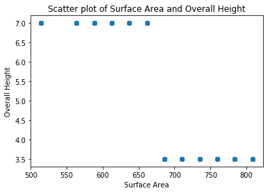

```python
# A scatter plot showing relationship between Surface Area and Overall Height
plt.scatter(energy_loads.loc[:, 'Surface Area'],
                energy_loads.loc[:, 'Overall Height'])
plt.xlabel('Surface Area')
plt.ylabel('Overall Height')
plt.title('Scatter plot of Surface Area and Overall Height')
```

With the above **surface area-vs-height scatter plot**, in combination with one of the box plots below (which shows that low height is associated with more energy efficiency), I wanted to provide one possible explanation for the result above, namely, why larger surface areas are associated with better energy efficiency. My explanation would be that there are two kinds of buildings in the data set - (A) taller buildings with smaller surface area and (B) lower buildings with larger surface area. So it seems that buildings (B) are more energy efficient

```
(0.0, 50.0)
```

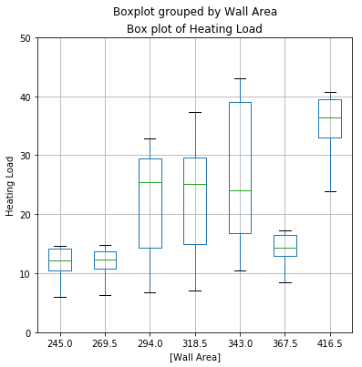

```python
# Create a box plot of Heating Load grouped by Wall Area
fig = plt.figure(figsize=(6, 6)) # Define plot area
ax = fig.gca() # Define axis
energy_loads.loc[:,['Heating Load', 'Wall Area']].boxplot(by = 'Wall Area', ax = ax)
ax.set_title('Box plot of Heating Load') # Give the plot a main title
ax.set_ylabel('Heating Load')# Set text for y axis
ax.set_ylim(0.0, 50.0) # Set the limits of the y axis
```

This chart might arguably be interpreted as meaning that the larger the wall area the higher the heating load.

```
(0.0, 50.0)
```

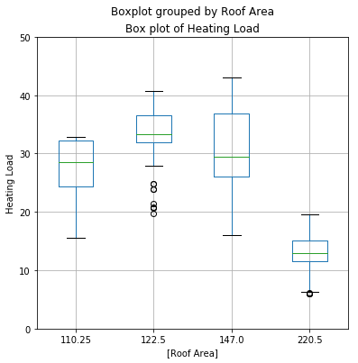

```python
# Create a box plot of Heating Load grouped by Roof Area
fig = plt.figure(figsize=(6, 6)) # Define plot area
ax = fig.gca() # Define axis
energy_loads.loc[:,['Heating Load', 'Roof Area']].boxplot(by = 'Roof Area', ax = ax)
ax.set_title('Box plot of Heating Load') # Give the plot a main title
ax.set_ylabel('Heating Load')# Set text for y axis
ax.set_ylim(0.0, 50.0) # Set the limits of the y axis
```

In this **roof area box plot**, it seems strange that the largest roof area is associated with the lowest Heating Load. One possible explanation is offered immediately below in a chart comparing the roof area, overall height and heating load.

```
(0.0, 50.0)
```

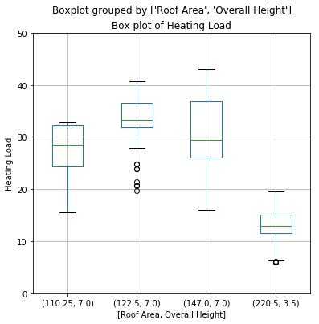

```python
# Create a box plot of Heating Load grouped by Roof Area and Overall Height
fig = plt.figure(figsize=(6, 6)) # Define plot area
ax = fig.gca() # Define axis
energy_loads.loc[:,['Heating Load', 'Roof Area', 'Overall Height']].boxplot(by = ['Roof Area', 'Overall Height'], ax = ax)
ax.set_title('Box plot of Heating Load') # Give the plot a main title
ax.set_ylabel('Heating Load')# Set text for y axis
ax.set_ylim(0.0, 50.0) # Set the limits of the y axis
```

This box plot shows that as roof area increases for high buildings (height value = 7.0, see the first 3 box plots) their energy efficiency worsens or at least stays at the same poor level, and the last box plot shows that for a very large roof area and a low building (height value = 3.5) the building's energy efficiency is good, which seems to be generally in line with my guess above that the dataset has 2 types of buildings - worse energy-efficient higher buildings and better engery-efficient lower buildings.

```
(0.0, 50.0)
```

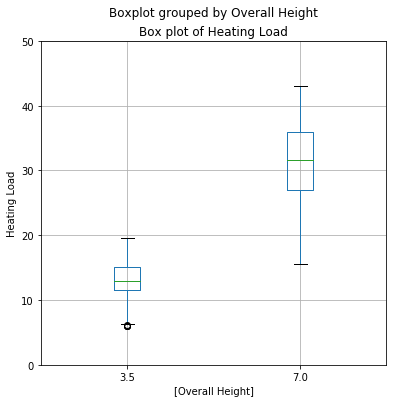

```python
# Create a box plot of Heating Load grouped by Overall Height
fig = plt.figure(figsize=(6, 6)) # Define plot area
ax = fig.gca() # Define axis
energy_loads.loc[:,['Heating Load', 'Overall Height']].boxplot(by = 'Overall Height', ax = ax)
ax.set_title('Box plot of Heating Load') # Give the plot a main title
ax.set_ylabel('Heating Load')# Set text for y axis
ax.set_ylim(0.0, 50.0) # Set the limits of the y axis
```

The above **overall height box plot** shows that larger height is associated with larger Heating Loads (i.e. with lower energy efficiency).

```
(0.0, 50.0)
```

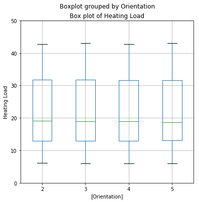

```python
# Create a box plot of Heating Load grouped by Orientation.
fig = plt.figure(figsize=(6, 6)) # Define plot area
ax = fig.gca() # Define axis
energy_loads.loc[:,['Heating Load', 'Orientation']].boxplot(by = 'Orientation', ax = ax)
ax.set_title('Box plot of Heating Load') # Give the plot a main title
ax.set_ylabel('Heating Load')# Set text for y axis
ax.set_ylim(0.0, 50.0) # Set the limits of the y axis
# This does not seem to give me a clue about the thermal load value
```

This should probably say that the building's orientation does not affect the energy efficiency of a building.

```
(0.0, 50.0)
```

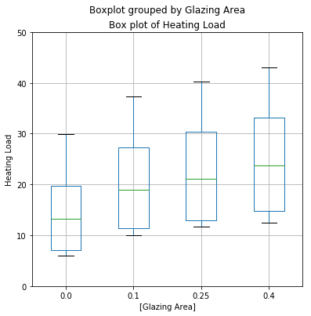

```python
# Create a box plot of Heating Load grouped by Glazing Area
fig = plt.figure(figsize=(6, 6)) # Define plot area
ax = fig.gca() # Define axis
energy_loads.loc[:,['Heating Load', 'Glazing Area']].boxplot(by = 'Glazing Area', ax = ax)
ax.set_title('Box plot of Heating Load') # Give the plot a main title
ax.set_ylabel('Heating Load')# Set text for y axis
ax.set_ylim(0.0, 50.0) # Set the limits of the y axis
# It is strange that the largest roof area is associated with the lowest Heating Load
```

The above **glazing area box plot** shows that more glazing makes a building less energy efficient which probably makes sense because there should be a lot of heat losses through glass windows.

```
(0.0, 50.0)
```

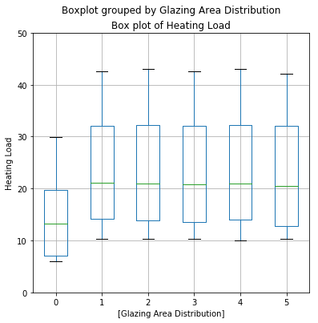

```python
# Create a box plot of Heating Load grouped by Orientation
# This must have something to do with the four cardinal directions, N, E, S, and W, I'd guess
fig = plt.figure(figsize=(6, 6)) # Define plot area
ax = fig.gca() # Define axis
energy_loads.loc[:,['Heating Load', 'Glazing Area Distribution']].boxplot(by = 'Glazing Area Distribution', ax = ax)
ax.set_title('Box plot of Heating Load') # Give the plot a main title
ax.set_ylabel('Heating Load')# Set text for y axis
ax.set_ylim(0.0, 50.0) # Set the limits of the y axis
# Glazing Area Distribution of 0 makes it very slightly more likely that the Heating Load is low
```

This should show that the glazing distribution around the building does not affect its energy efficiency. It is unclear what the first box plot shows because I don't know what the value of 0 is in the glazing area distribution means.

### Conclusions:

As a **first general note**, I think that looking at each indicator alone would not always make sense - it should be the combination of them that affects the energy efficiency of buildings. Some relationships only make sense when several variables are taken into account, see, for example, this surface area chart and this roof area chart.

As a **second note**, I compared all indicators to the Heating Load and ignored the Cooling Load parameter because these two thermal loads are almost identical (see this thermal loads box plot).

As a **third note**, there is a duplication in the data in the variables Relative Compactness and Surface Area - as this scatter plot and this cross table show, these variables contain the same data.

My conclusion from the charts above about the energy efficiency of the buildings is that:

(1) There are two kinds of buildings in the data set:

```
 (A) taller ones with smaller surface area - these are less energy efficient

 (B) lower ones with larger surface area - these are more energy efficeint
```

The relationship between height and surface area can be seen in this scatter plot - this plot shows that there are 2 kinds of buildings in the dataset - taller ones (height = 7.0 m) with area below appox. 675 m2 and lower ones (height = 3.5 m) with area above 675 m2. The higher buildings in this dataset have lower energy efficiency and the lower buildings have higher energy efficiency - please see point (3) below.

(2) The heating load of buildings in this dataset is associated with their Glazing Area. As the glazing area increases, the heating load increases too. Evidence for this relationship can be seen in this box plot.

(3) The heating load of the buildings in this dataset can be divided into two clearly separated groups depending on the Overall Height of the buildigs. See this box plot which shows that larger height is associated with larger heating loads and lower height is with lower heating loads.